# P5_MartinOkanik

# K-Nearest Neighbours

4. **Create class predictions for the test set using the `knn()` function. Use `student`, `balance`, and `income` (but no basis functions of those variables) in the `default_train` dataset. Set `k` to 5. Store the predictions in a variable called `knn_5_pred`.**

```r
#knn_5_pred <- knn(default_train %>% select(student, balance, income),
#                  default_test %>% select(student, balance, income),
#                  cl = as_factor(default_train %>% select(default)),
#                  k = 5)
```

```r
knn_5_pred <- knn(default_train %>% select(-default),
                  default_test %>% select(-default),
                  default_train$default,
                  k = 5)
```

5. **Create two scatter plots with income and balance as in the first plot you made. One with the true class (`default`) mapped to the colour aesthetic, and one with the predicted class (`knn_5_pred`) mapped to the colour aesthetic.**

   *Hint: Add the predicted class `knn_5_pred` to the `default_test` dataset before starting your `ggplot()` call of the second plot. What do you see?*

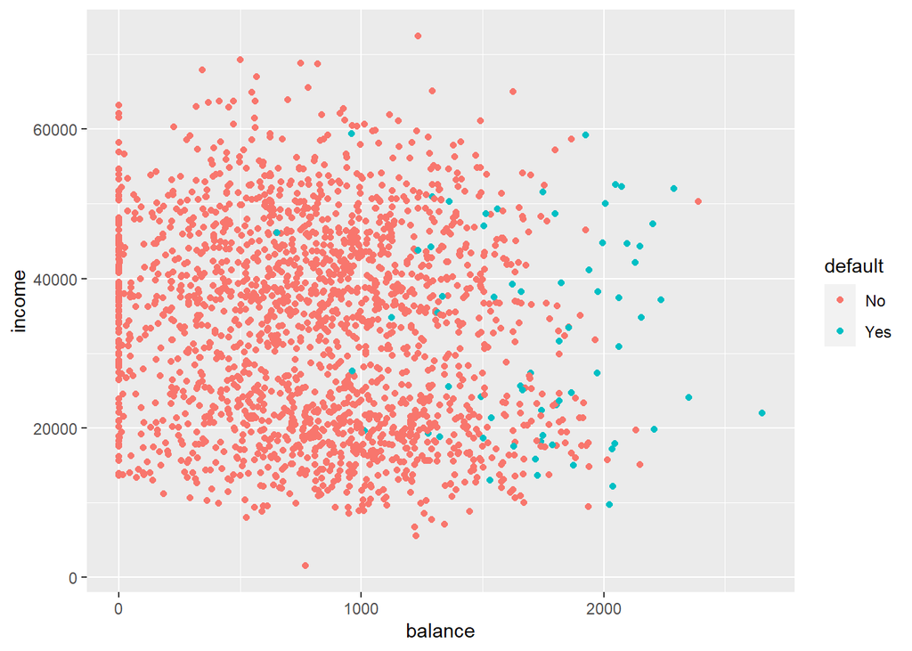

```r
default_test %>%
  ggplot(aes(x = balance, y = income, colour = default)) +
  geom_point()
```

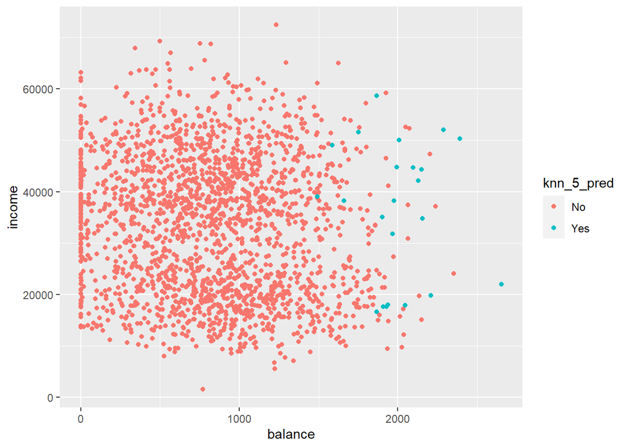

```r
default_test %>%
  mutate(knn_5_pred = knn_5_pred) %>%
  ggplot(aes(x = balance, y = income, colour = knn_5_pred)) +
  geom_point()
```

There are way less predicted defaults than observed. There are generally lots of misclassifications.

6. **Repeat the same steps, but now with a `knn_2_pred` vector generated from a 2-nearest neighbours algorithm. Are there any differences?**

```r
knn_2_pred <- knn(default_train %>% select(-default),
                  default_test %>% select(-default),
                  default_train$default,
                  k = 2)

head(default_test)
```

```
##   default   balance student   income
## 1      No  304.1466       0 23866.94
## 2      No  353.6311       0 40686.76
## 3      No 1269.4203       0 39010.15
## 4      No  397.5425       1 22710.87
## 5      No  607.1663       0 49547.47
## 6      No 1667.4804       0 47991.59
```

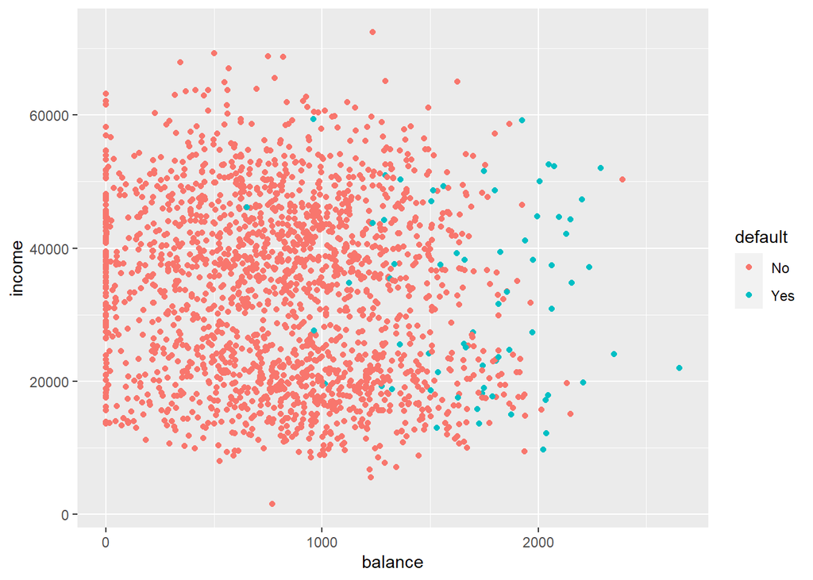

```r
default_test %>%
  ggplot(aes(x = balance, y = income, colour = default)) +
  geom_point()
```

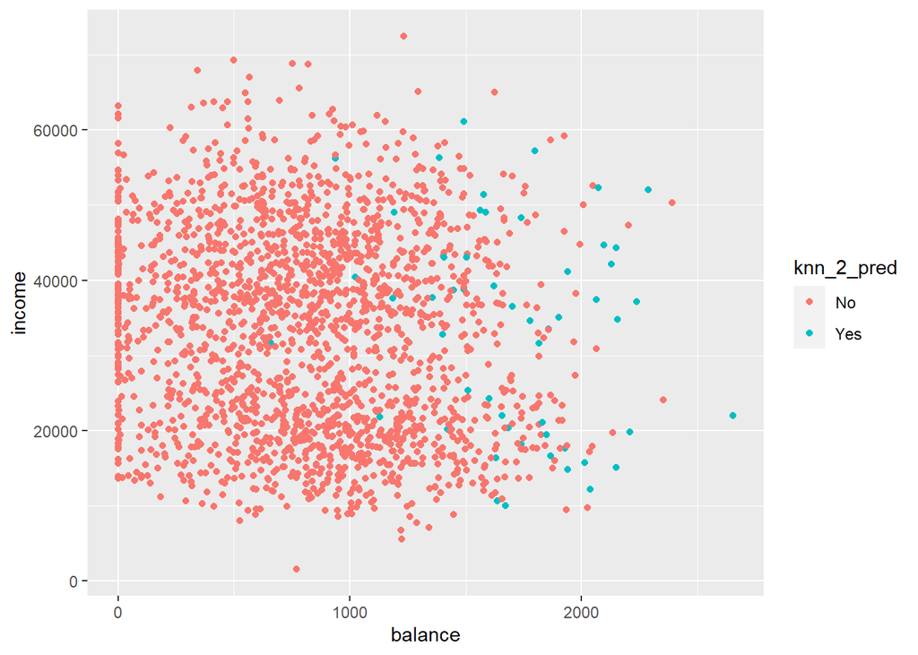

```r
default_test %>%
  mutate(knn_2_pred = knn_2_pred) %>%
  ggplot(aes(x = balance, y = income, colour = knn_2_pred)) +
  geom_point()
```

A bit better (more “Yes” found), but still lacking.

# Confusion matrix

The confusion matrix is an insightful summary of the plots we have made and the correct and incorrect classifications therein. A confusion matrix can be made in `R` with the `table()` function by entering two `factor`s:

[output not shown]

7. **What would this confusion matrix look like if the classification were perfect?**

   it would be diagonal
8. **Make a confusion matrix for the 5-nn model and compare it to that of the 2-nn model. What do you conclude?**

```r
table(true = default_test$default, predicted = knn_5_pred)
```

```
##      predicted
## true    No  Yes
##   No  1923   10
##   Yes   54   13
```

Despite my first impressions from the graph, 5-nn model is actually better. It finds less positive cases overall, but the primary reason why 2-nn finds more is that it finds a lot of FP, only marginally better TP than 5-nn (15 vs 13). Accuracy is better for 5-nn.

# Logistic regression

9. **Use `glm()` with argument `family = binomial` to fit a logistic regression model `lr_mod` to the `default_train` data.**

```r
lr_mod <- default_train %$% glm(default ~ student + income + balance, family = binomial)
```

Now we have generated a model, we can use the `predict()` method to output the estimated probabilities for each point in the training dataset. By default `predict` outputs the log-odds, but we can transform it back using the inverse logit function of before or setting the argument `type = "response"` within the predict function.

10. **Visualise the predicted probabilities versus observed class for the training dataset in `lr_mod`. You can choose for yourself which type of visualisation you would like to make. Write down your interpretations along with your plot.**

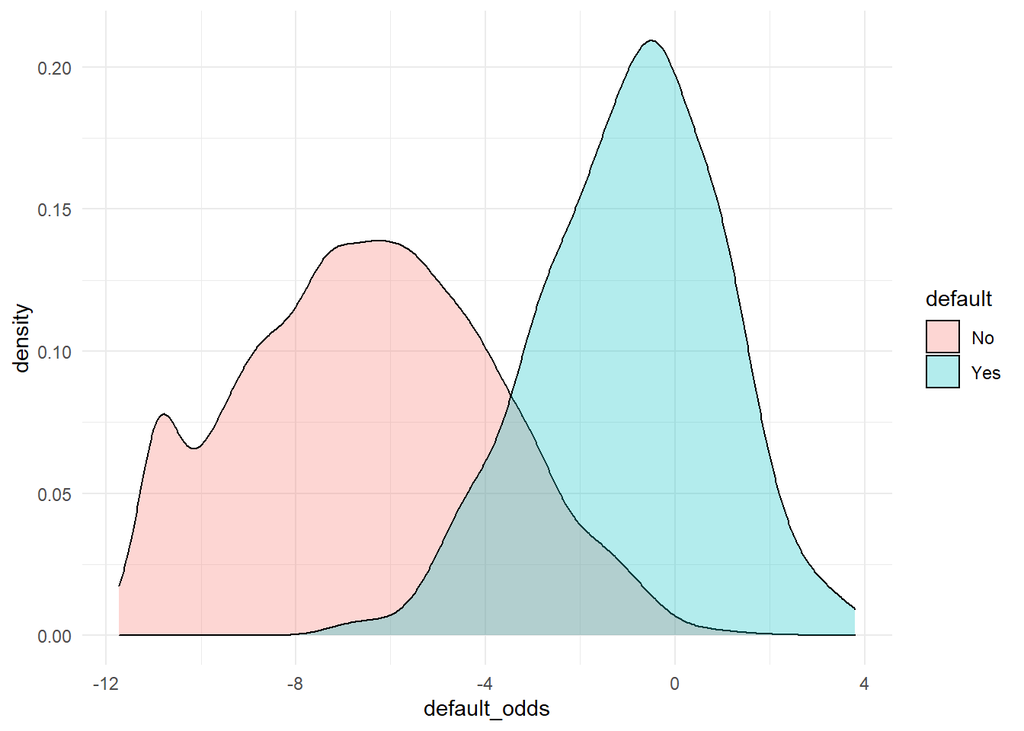

```r
default_train %>%
  mutate(default_odds = predict(lr_mod)) %>%
  ggplot(aes(x = default_odds, fill = default)) +
  geom_density(alpha = 0.3) +
  theme_minimal()
```

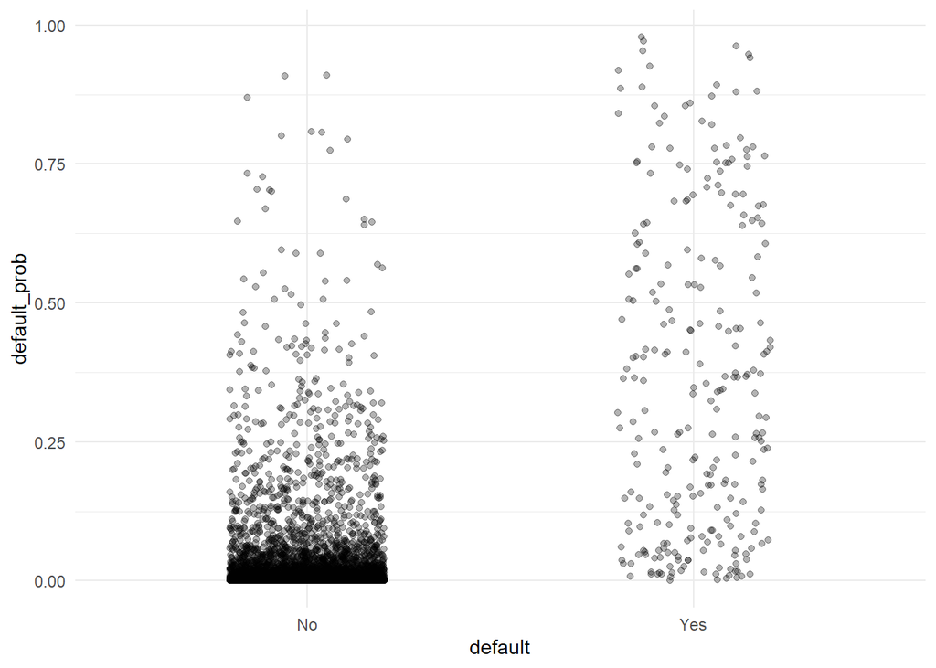

```r
default_train %>%
  mutate(default_prob = predict(lr_mod, type="response")) %>%
  ggplot(aes(x = default, y = default_prob)) +
  geom_point(position = position_jitter(width = 0.2), alpha = 0.3) +
  theme_minimal()
```

We see that the distribution of probabilities assigned by the model inside the subset of non-defaulting people is very heavily dominated by values below 0.10, with a few offshoots with higher probabilities. Distribution of model-assigned probabilites for the defaulting subset is more or less uniform.

Another advantage of logistic regression is that we get coefficients we can interpret.

11. **Look at the coefficients of the `lr_mod` model and interpret the coefficient for `balance`. What would the probability of default be for a person who is not a student, has an income of 40000, and a balance of 3000 dollars at the end of each month? Is this what you expect based on the plots we’ve made before?**

```r
lr_mod
```

```
##
## Call:  glm(formula = default ~ student + income + balance, family = binomial)
##
## Coefficients:
## (Intercept)      student       income      balance
##  -1.118e+01   -6.034e-01    5.614e-06    5.881e-03
##
## Degrees of Freedom: 7999 Total (i.e. Null);  7996 Residual
## Null Deviance:       2334
## Residual Deviance: 1236  AIC: 1244
```

Coefficient for balance is +5.881e-03. This means that the probability of default increases with increasing balance. To answer the second question:

```r
lr_mod %>% predict(newdata = tibble(balance = 3000, student = 0, income = 40000),
                   type = "response")
```

```
##         1
## 0.9987547
```

## Visualising the effect of the balance variable

12. **Create a data frame called `balance_df` with 3 columns and 500 rows: `student` always 0, `balance` ranging from 0 to 3000, and `income` always the mean income in the `default_train` dataset.**

```r
balance_df <- data.frame(student = 0 * 1:500,
                         balance = 6 * 1:500,
                         income = rep(mean(default_train$income), 500) )
head(balance_df)
```

```
##   student balance   income
## 1       0       6 33547.82
## 2       0      12 33547.82
## 3       0      18 33547.82
## 4       0      24 33547.82
## 5       0      30 33547.82
## 6       0      36 33547.82
```

```r
# other option for balance: seq(0, 3000, length.out = 500)
```

13. **Use this dataset as the `newdata` in a `predict()` call using `lr_mod` to output the predicted probabilities for different values of `balance`. Then create a plot with the `balance_df$balance` variable mapped to x and the predicted probabilities mapped to y. Is this in line with what you expect?**

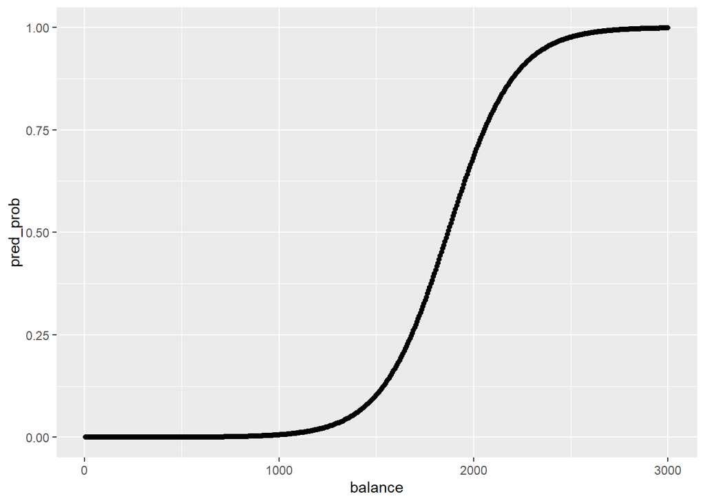

```r
balance_df %>%
  mutate(pred_prob = predict(lr_mod, ., type = "response" )) %>%
  ggplot(aes(x = balance, y = pred_prob)) +
  geom_point()
```

This is a sigmoid function in balance, which is precisely what we would expect from a logistic regression model.

14. **Create a confusion matrix just as the one for the KNN models by using a cutoff predicted probability of 0.5. Does logistic regression perform better?**

```r
pred_probs <- lr_mod %>%
  predict(newdata = default_test, type = "response")

pred_lr <- factor(pred_probs > 0.5, labels = c("Yes", "No"))

table(true = default_test$default, predicted = pred_lr)
```

```
##      predicted
## true   Yes   No
##   No  1923   10
##   Yes   43   24
```

# Linear discriminant analysis

The last method we will use is LDA, using the `lda()` function from the `MASS` package.

15. **Train an LDA classifier `lda_mod` on the training set.**

```r
lda_mod <- lda(default ~ balance + student + income, default_train)
```

16. **Look at the `lda_mod` object. What can you conclude about the characteristics of the people who default on their loans?**

```r
lda_mod
```

```
## Call:
## lda(default ~ balance + student + income, data = default_train)
##
## Prior probabilities of groups:
##      No     Yes
## 0.96675 0.03325
##
## Group means:
##       balance   student   income
## No   801.8761 0.2895009 33604.83
## Yes 1751.2716 0.3984962 31890.15
##
## Coefficients of linear discriminants:
##                   LD1
## balance  2.245385e-03
## student -1.070219e-01
## income   5.124669e-06
```

People who default have on average >2x higher balance, very slightly smaller income and are more likely to be students, by a third.

17. **Create a confusion matrix and compare it to the previous methods.**

```r
table(true = default_test$default,
      predicted = predict(lda_mod, newdata = default_test)$class)
```

```
##      predicted
## true    No  Yes
##   No  1930    3
##   Yes   49   18
```

This tends to under-detect the defaults.

# Final assignment

18. **Create a model (using knn, logistic regression, or LDA) to predict whether a 14 year old boy from the 3rd class would have survived the Titanic disaster. You can find the data in the `data/` folder. Would the passenger have survived if they were a girl in 2nd class?**

```r
Titanic <- read.csv("Titanic.csv")
titanic <- Titanic[sample(nrow(Titanic)), ]
head(titanic)
```

```
##                               Name PClass Age    Sex Survived
## 861         Hellstrom, Hilda Maria    3rd  22 female        1
## 1046             Murphy, Miss Nora    3rd  NA female        0
## 50        Carter, Miss Lucile Polk    1st  14 female        1
## 1261 Touma (Thomas), Master George    3rd  NA   male        0
## 161               Lewy, Mr Ervin G    1st  NA   male        0
## 1108            Paulner, Mr Uscher    3rd  NA   male        0
```

```r
lrm <- titanic %$% glm(Survived ~ PClass + Age + Sex, family = "binomial")
lrm
```

```
##
## Call:  glm(formula = Survived ~ PClass + Age + Sex, family = "binomial")
##
## Coefficients:
## (Intercept)    PClass2nd    PClass3rd          Age      Sexmale
##     3.75966     -1.29196     -2.52142     -0.03918     -2.63136
##
## Degrees of Freedom: 755 Total (i.e. Null);  751 Residual
##   (557 observations deleted due to missingness)
## Null Deviance:       1026
## Residual Deviance: 695.1     AIC: 705.1
```

```r
predict(lrm, newdata = tibble(PClass = "3rd", Age = 14, Sex = "male"), type = "response" )
```

```
##         1
## 0.1254734
```

A poor boy would likely not survive.

*“I’m just a poooor boy, I need no sympathy. Because I’m easy come, easy go…”*

```r
predict(lrm, newdata = tibble(PClass = "3rd", Age = 14, Sex = "female"), type = "response" )
```

```
##         1
## 0.6659152
```